# Ford Gobike.

# Effects of data characters on duration of trip

## by Iboudullaev Fazliddin

## Investigation Overview

> I want to view the impact of different data characters on trip duration. My data characters are start-end stations, user type, rental access method and bike id.

## Dataset Overview

> My dateset contains 176799 entries. There are 14 columns which are duration_sec, start_time, end_time, start_station_id, start_station_name, start_station_latitude, start_station_longitude, end_station_id, end_station_name, end_station_latitude, end_station_longitude, bike_id, user_type, rental_access_method.

## Distribution of trip durations

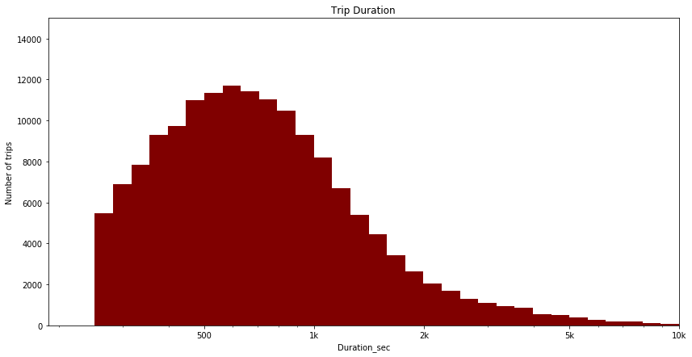

```python
#As you can see from above plot, tail is too long. Let us use log scale then
log_binsize = 0.05
bins_log = 10 ** np.arange(2.4, np.log10(df.duration_sec.max())+log_binsize, log_binsize)

#for sizing the plot
plt.figure(figsize=[14, 7])

#plotting the histogram
plt.hist(data = df, x = 'duration_sec', bins = bins_log, color='maroon')
plt.title('Trip Duration')
plt.xlabel('Duration_sec')
plt.ylabel('Number of trips')
plt.xscale('log')
plt.xticks([500, 1e3, 2e3, 5e3, 1e4], [500, '1k', '2k', '5k', '10k'])
plt.axis([0, 10000, 0, 15000]);
```

## Start and end station distribution

> Apparently, the start and end stations are the same.

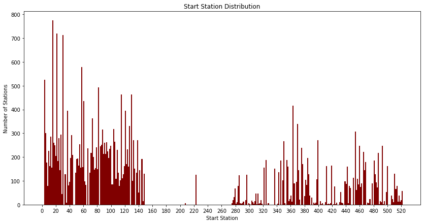

```python
#on standard scale I try to plot start station id distribution
binsize = 1.5
bins = np.arange(0, df.start_station_id.max()+binsize, binsize)

#for sizing the plot
plt.figure(figsize=[14, 7])

#plotting the histogram
plt.hist(data = df.dropna(), x = 'start_station_id', bins = bins, color='maroon')
plt.title('Start Station Distribution')
plt.xlabel('Start Station')
plt.ylabel('Number of Stations')
plt.xticks(range(0, 540, 20));
```

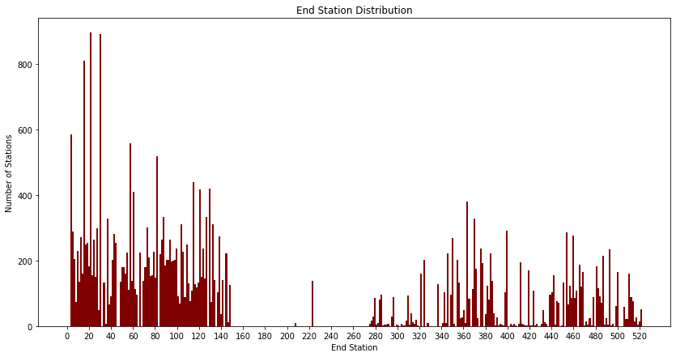

```python
#on standard scale I try to plot end station id distribution
binsize = 1.5
bins = np.arange(0, df.end_station_id.max()+binsize, binsize)

#for sizing the plot
plt.figure(figsize=[14, 7])

#plotting the histogram
plt.hist(data = df.dropna(), x = 'end_station_id', bins = bins, color='maroon')
plt.title('End Station Distribution')
plt.xlabel('End Station')
plt.ylabel('Number of Stations')
plt.xticks(range(0, 540, 20));
```

## Trip duration and user type

> Apparently, the customers are more willing to take long trips than subscribers.

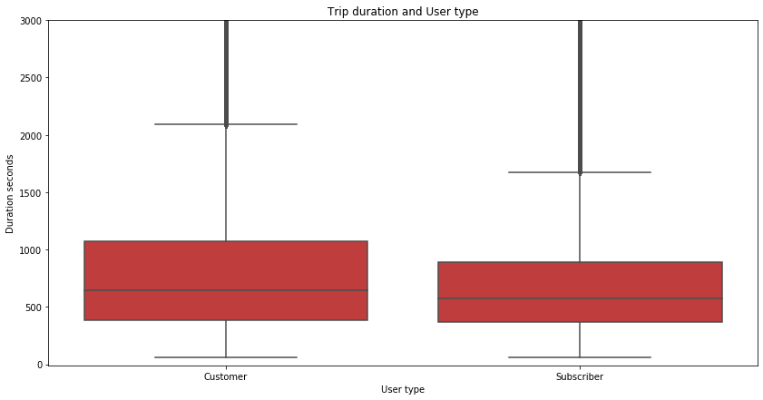

```python
plt.figure(figsize=[14,7])
base_color = sb.color_palette()[3]
sb.boxplot(data = df, x = 'user_type', y = 'duration_sec', color=base_color)
plt.title('Trip duration and User type')
plt.xlabel('User type')
plt.ylabel('Duration seconds')
plt.ylim(-10, 3000);
```

## Trip duration and rental access method

> If you look at the rental accessing method deeper, you will realize that people who use app takes long trips than clipper.

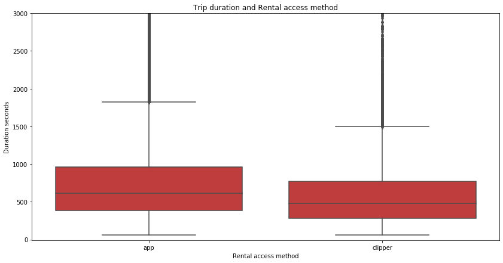

```python
plt.figure(figsize=[14,7])
base_color = sb.color_palette()[3]
sb.boxplot(data = df, x = 'rental_access_method', y = 'duration_sec', color=base_color)
plt.title('Trip duration and Rental access method')
plt.xlabel('Rental access method')
plt.ylabel('Duration seconds')
plt.ylim(-10, 3000);
```

## Trip duration per User type and Rental access method

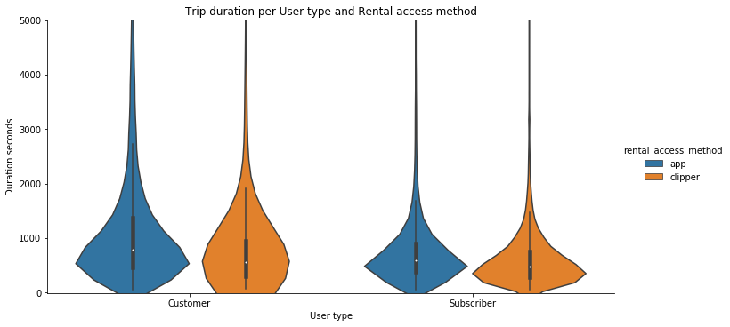

```python
plt.figure(figsize=[14,7])
sb.catplot(data=df, x='user_type', y='duration_sec', hue = 'rental_access_method', kind='violin', height=5, aspect=2)
plt.title('Trip duration per User type and Rental access method')
plt.xlabel('User type')
plt.ylabel('Duration seconds')
plt.ylim(-10, 5000);
```

## Trip Duration, user type, and bike_id

> Interestingly subscribers take bikes not quite often. Whereas customers take bikes very often and trip duration is also very long.

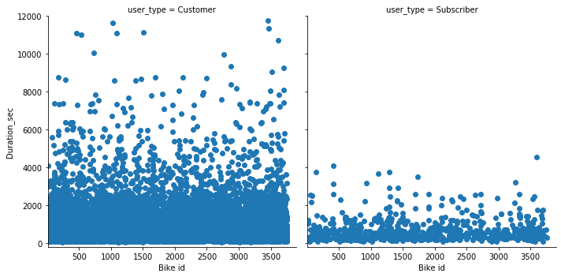

```python
user_type = sb.FacetGrid(data = df, col = 'user_type', col_wrap = 2, size = 5, xlim = [10, 3900], ylim = [-200, 12000])
user_type.map(plt.scatter, 'bike_id', 'duration_sec', alpha= 1)

user_type.set_xlabels('Bike id')
user_type.set_ylabels('Duration_sec');
```